# Paired Samples Difference Tests

## Paired samples difference tests

Often in second language research, we want to know if participants’ performance changes over time (perhaps in relation to a particular instructional method) using a pre-test and a post-test. Because the same individuals complete the pre-test and post-test, we do NOT meet the assumption of independence, so we cannot use an independent samples t-test. Fortunately, there are multiple methods for measuring differences in paired samples. In this tutorial, we will discuss the dependent samples t-test and the Wilcoxon signed rank test. Note that in some studies, we actually have more than two tests (e.g., a pre-test, a post-test, and a delayed post test). In such a case, we would need to use a repeated measures ANOVA or a linear-mixed effects model (these will be covered in upcoming tutorials).

### Data for this tutorial

The data for this tutorial comprise concreteness scores, range scores, proportion of 1,000 word list words, proportion of 2000 word list words, and proportion of academic word list (AWL) words for 500 L2 English essays written by L1 users of Mandarin Chinese. Each participant wrote two essays. One of these essays was written in response to a “part-time job” prompt, and the other to a “smoking” prompt. See the (ICNALE corpus)[http://language.sakura.ne.jp/icnale/] for further information about the characteristics of the learner corpus. The essays were processed using (TAALES)[https://www.linguisticanalysistools.org/taales.html] and another in-house Python script to generate the index scores.

```r
mydata <- read.csv("data/paired_samples_data.csv", header = TRUE)
summary(mydata)
```

```
##          Participant  Prompt       n_words      Classic_1K_Tokens
##  W_CHN_001_B1_1:  2   PTJ:250   Min.   :179.0   Min.   :0.7127
##  W_CHN_002_B1_1:  2   SMK:250   1st Qu.:210.0   1st Qu.:0.8009
##  W_CHN_003_B1_1:  2             Median :223.0   Median :0.8549
##  W_CHN_004_B1_2:  2             Mean   :230.6   Mean   :0.8471
##  W_CHN_005_B1_2:  2             3rd Qu.:244.0   3rd Qu.:0.8945
##  W_CHN_006_B1_2:  2             Max.   :342.0   Max.   :0.9665
##  (Other)       :488
##  Classic_2K_Tokens  Classic_AWL_Tokens MRC_Concreteness_AW
##  Min.   :0.008584   Min.   :0.00000    Min.   :275.1
##  1st Qu.:0.034578   1st Qu.:0.01951    1st Qu.:299.3
##  Median :0.072904   Median :0.03866    Median :305.1
##  Mean   :0.082979   Mean   :0.03926    Mean   :305.5
##  3rd Qu.:0.130045   3rd Qu.:0.05717    3rd Qu.:311.5
##  Max.   :0.182320   Max.   :0.09796    Max.   :333.2
##
##  MRC_Concreteness_CW SUBTLEXus_Range_AW SUBTLEXus_Range_CW
##  Min.   :326.4       Min.   :4689       Min.   :2665
##  1st Qu.:356.6       1st Qu.:5662       1st Qu.:3718
##  Median :369.0       Median :5900       Median :4065
##  Mean   :369.6       Mean   :5911       Mean   :4129
##  3rd Qu.:380.9       3rd Qu.:6169       3rd Qu.:4540
##  Max.   :424.5       Max.   :6936       Max.   :5772
##
```

Note that the summary() function above doesn’t quite tell us what we want to know, since we want to see how our groups differ. We can use the “describeBy” function in the “psych” package to compare our groups.

```r
library(psych)
describeBy(mydata$MRC_Concreteness_AW, mydata$Prompt)
```

```
##
##  Descriptive statistics by group
## group: PTJ
##    vars   n   mean   sd median trimmed  mad    min    max range skew
## X1    1 250 304.07 8.77 303.89  303.78 8.07 285.24 331.82 46.58 0.36
##    kurtosis   se
## X1     0.24 0.55
## --------------------------------------------------------
## group: SMK
##    vars   n mean   sd median trimmed  mad    min    max range skew
## X1    1 250  307 9.77 306.31  306.95 9.65 275.12 333.23 58.11 0.02
##    kurtosis   se
## X1     0.03 0.62
```

In order to ensure that our paired samples tests are conducted correctly, we will also order our data by participant.

```r
library(dplyr) #load dplyr
mydata.2 <-arrange(mydata, Participant, Prompt) #sort by Participant, then by prompt
head(mydata.2) #check the first few entries to make sure things are sorted correctly
```

```
##      Participant Prompt n_words Classic_1K_Tokens Classic_2K_Tokens
## 1 W_CHN_001_B1_1    PTJ     262         0.8750000        0.04411765
## 2 W_CHN_001_B1_1    SMK     220         0.7762557        0.13698630
## 3 W_CHN_002_B1_1    PTJ     201         0.9014778        0.02955665
## 4 W_CHN_002_B1_1    SMK     299         0.8282828        0.11784512
## 5 W_CHN_003_B1_1    PTJ     236         0.9166667        0.02916667
## 6 W_CHN_003_B1_1    SMK     255         0.7874016        0.15354331
##   Classic_AWL_Tokens MRC_Concreteness_AW MRC_Concreteness_CW
## 1        0.058823529            309.0459            368.2685
## 2        0.027397260            307.6379            386.1000
## 3        0.064039409            295.7416            342.8409
## 4        0.026936027            291.0928            360.6436
## 5        0.037500000            321.1571            384.7647
## 6        0.003937008            319.6798            380.8056
##   SUBTLEXus_Range_AW SUBTLEXus_Range_CW
## 1           6023.526           4404.554
## 2           5783.734           3783.229
## 3           6074.050           4233.294
## 4           5863.631           3956.669
## 5           5901.640           4448.389
## 6           5615.510           3960.383
```

### Visualizing the data

One way to visualize the data is to use box plots, much like we did with our independent samples t-test.

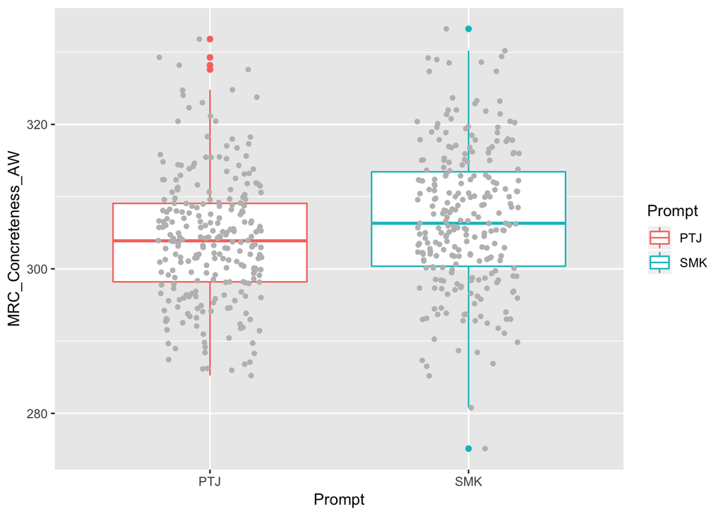

```r
library(ggplot2)
ggplot(mydata.2, aes(x=Prompt,y=MRC_Concreteness_AW, color = Prompt)) +
  geom_boxplot() +
  geom_jitter(shape=16, position=position_jitter(0.2), color = "grey")
```

While this view gives us a general impression of the differences between the two prompts, it DOESN’T show us differences by individual. The following plot will be a little messy because we have 250 participants. However, most studies will have far fewer particpants (which results in a cleaner plot).

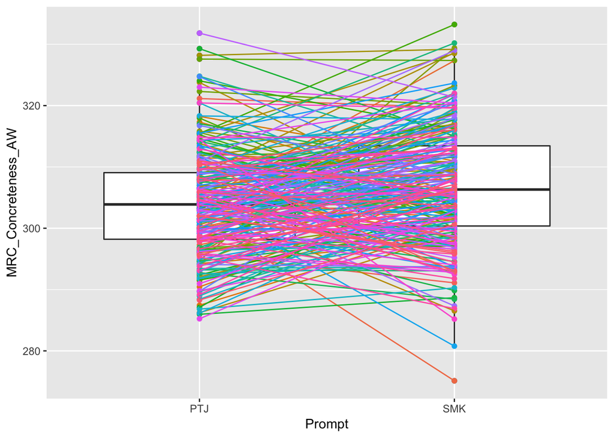

```r
ggplot(mydata.2, aes(x=Prompt,y=MRC_Concreteness_AW)) +
  geom_boxplot() +
  geom_point(aes(color = Participant), show.legend = FALSE) +
  geom_line(aes(group = Participant, color = Participant), show.legend = FALSE)
```

Just for illustrative purposes, lets pretend that our dataset only included the first 15 participants in our larger dataset.

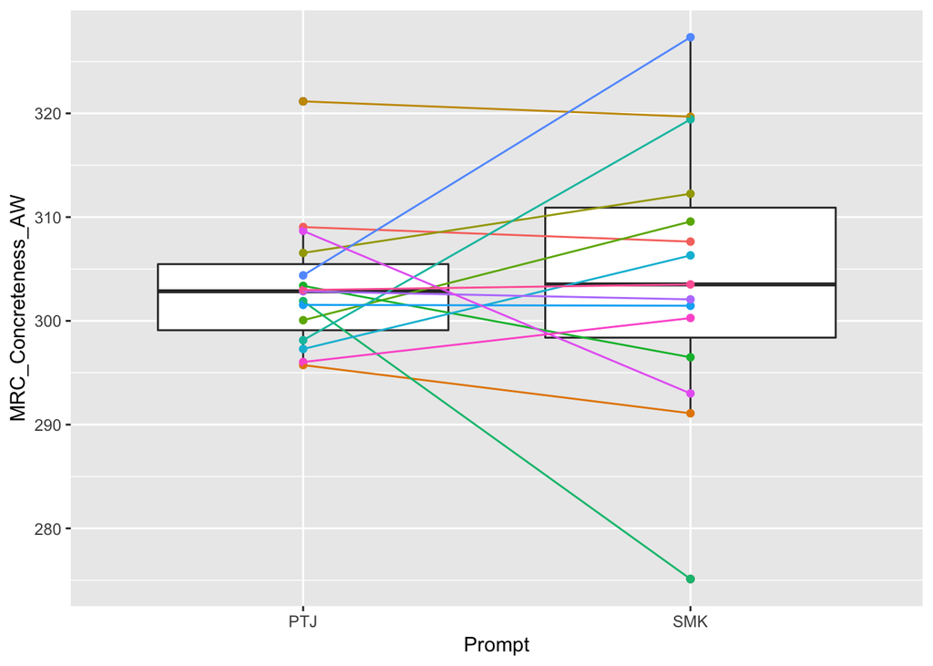

```r
mydata.3 <- mydata.2[1:30, ] #create new dataframe with the first 30 rows from mydata.2
ggplot(mydata.3, aes(x=Prompt,y=MRC_Concreteness_AW)) +
  geom_boxplot() +
  geom_point(aes(color = Participant), show.legend = FALSE) +
  geom_line(aes(group = Participant, color = Participant), show.legend = FALSE)
```

### Dependent samples T-test

To conduct a dependent samples T-test, we first have to check for assumptions. These assumptions are almost exactly the same as for an independent samples T-test:

- The observations must be independent (within each sample)
- Each sample is normally distributed, and the variance is equal across samples
- There is only one comparison (an ANOVA is appropriate for multiple comparisons, stay tuned)
- The data is continuous

First, we can check visually for normality. Note that we will use a “group” in ggplot and will also add “facet_wrap”, which allows us to see individual plots for each level of a categorical variable.

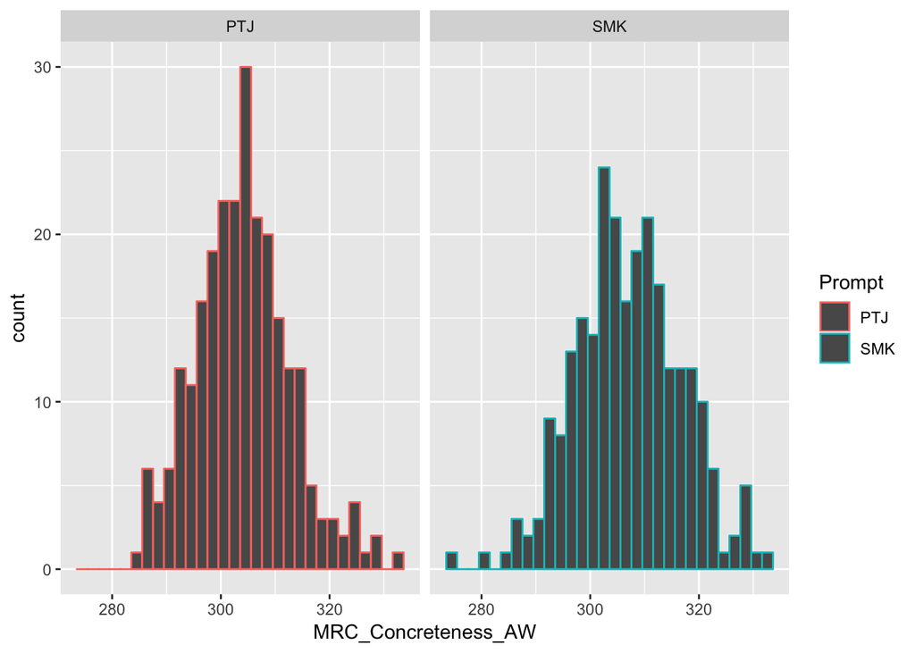

```r
ggplot(mydata.2, aes(x = MRC_Concreteness_AW, group = Prompt, color = Prompt))+
  geom_histogram() +
  facet_wrap(~Prompt)
```

Our data looks roughly normal, so we will proceed with the tutorial. However, be sure to check the other assumptions (and use other tests of normality) on your own.

Now, lets check to see if concreteness scores (MRC_Concretesess_AW) differ across the two prompts.

```r
t.test(MRC_Concreteness_AW~Prompt, paired = TRUE, data = mydata.2)
```

```
##
##  Paired t-test
##
## data:  MRC_Concreteness_AW by Prompt
## t = -4.3958, df = 249, p-value = 1.636e-05
## alternative hypothesis: true difference in means is not equal to 0
## 95 percent confidence interval:
##  -4.245634 -1.618281
## sample estimates:
## mean of the differences
##               -2.931957
```

The results indicate that the differences between the two prompts are indeed significantly different (p = .00001636).

Now, we will check the effect size using Cohen’s d:

```r
library(psych)
cohen.d(mydata.2,"Prompt")
```

```
## Call: cohen.d(x = mydata.2, group = "Prompt")
## Cohen d statistic of difference between two means
##                     lower effect  upper
## Participant         -0.18   0.00  0.175
## n_words             -0.41  -0.24 -0.058
## Classic_1K_Tokens   -3.60  -3.27 -2.930
## Classic_2K_Tokens    4.66   5.15  5.630
## Classic_AWL_Tokens  -2.75  -2.47 -2.194
## MRC_Concreteness_AW  0.14   0.32  0.494
## MRC_Concreteness_CW  0.91   1.11  1.313
## SUBTLEXus_Range_AW  -1.35  -1.15 -0.945
## SUBTLEXus_Range_CW  -1.68  -1.46 -1.244
##
## Multivariate (Mahalanobis) distance between groups
## [1] 6.5
## r equivalent of difference between two means
##         Participant             n_words   Classic_1K_Tokens
##                0.00               -0.12               -0.85
##   Classic_2K_Tokens  Classic_AWL_Tokens MRC_Concreteness_AW
##                0.93               -0.78                0.16
## MRC_Concreteness_CW  SUBTLEXus_Range_AW  SUBTLEXus_Range_CW
##                0.49               -0.50               -0.59
```

If we look at the entry for MRC_Concreteness, we see that our effect size (d = .32) represents a small effect (see tutorial 9).

### Paired samples Wilcoxon signed rank test

If our data do not meet the assumptions of the paired samples T-test, we can use the paired samples Wilcoxon signed rank test.

This test is easy to compute in R:

```r
wilcox.test(MRC_Concreteness_AW~Prompt, paired = TRUE, data = mydata.2)
```

```
##
##  Wilcoxon signed rank test with continuity correction
##
## data:  MRC_Concreteness_AW by Prompt
## V = 10656, p-value = 1.104e-05
## alternative hypothesis: true location shift is not equal to 0
```

We then compute the effect size:

```r
library(rcompanion) #don't forget to install if you haven't already
wilcoxonR(mydata.2$MRC_Concreteness_AW,mydata.2$Prompt)
```

```
##     r
## 0.161
```

Our effect size is small (r = .161), according to Cohen’s (1988) guidelines for r.

### Sign test

Another alternative is the Sign test. This takes a little more work to run in R, but is still fairly simple.

```r
#create filtered versions of each variable
concreteness.smk = mydata.2$MRC_Concreteness_AW [mydata.2$Prompt == "SMK"]
concreteness.ptj = mydata.2$MRC_Concreteness_AW [mydata.2$Prompt == "PTJ"]
#load library
library(BSDA)
#run sign test
SIGN.test(x = concreteness.smk, y = concreteness.ptj, alternative = "two.sided", conf.level = 0.95)
```

```
##
##  Dependent-samples Sign-Test
##
## data:  concreteness.smk and concreteness.ptj
## S = 156, p-value = 0.0001061
## alternative hypothesis: true median difference is not equal to 0
## 95 percent confidence interval:
##  1.316834 5.096621
## sample estimates:
## median of x-y
##      3.028521
##
## Achieved and Interpolated Confidence Intervals:
##
##                   Conf.Level L.E.pt U.E.pt
## Lower Achieved CI     0.9336 1.6432 4.7569
## Interpolated CI       0.9500 1.3168 5.0966
## Upper Achieved CI     0.9503 1.3110 5.1027
```

As we see, the Sign test also indicates that there is a significant difference in concreteness scores across the two prompts (p = .0001061).